# pa5

Joselyn Rodriguez

3/29/2021

```r
library(tidyverse)
library(psych)
```

### Programming Assignment 5 (midterm)

#### TLDR: you want to know if proficiency scores vary as a function of age (younger/older) and composite aptitude score.

### 5. Load the dataset from your index.Rmd file. Pay special attention to the path. Don’t forget where the .csv file lives. Print the first 6 rows of the dataframe.

```r
data <- read_csv("data_raw/pa_5_data/lang_data_raw.csv")
head(data, row = 6)
```

```
## # A tibble: 6 x 4
##   id                  iq motivation  prof
##   <chr>            <dbl>      <dbl> <dbl>
## 1 p01_male_older    97.0       1.47  0.67
## 2 p02_female_older  91.5       1.31  0.46
## 3 p03_male_older    97.2       1.48  0.55
## 4 p04_female_older  91.5       1.31  0.49
## 5 p05_male_older    96.0       1.44  0.59
## 6 p06_female_older  93.8       1.37  0.62
```

### 6. Tidy the dataset. Keep in mind the principles of tidy data. Use sections, text, comments, etc. to explain every step of the process.

#### 7. Create a new column in the dataset for the composite language learning score by taking the log of iq divided by 80 plus the log of motivation. Call this variable composite_score. After you have created this variable, you can standardize or center it if you want (i.e., create z-scores, or subtract the mean from each value), but this is not obligatory.

```r
# separate the "id" variable into subject, gender, and age as well a create new variable "composite_score"
data_tidy <- data %>%
              separate("id", into = c("subject", "gender", "age")) %>%
              mutate(temp = (log(iq/80)) + log(motivation)) %>%
              mutate(composite_score = ((temp - mean(temp))/sd(temp)))
# write_csv(data_tidy, "data_clean/data_tidy.csv") # saving data
```

### 8. Provide a table of descriptive statistics. You decide what is relevant based on the variables you have and your hypotheses. Include any observations you can make from the table.

```r
data_framed <- as.data.frame(data_tidy) # because you can't use tibbles with this function

# just some general tables to check values through various groupings
describe(data_framed)
```

```
##                 vars   n   mean    sd median trimmed   mad   min    max  range
## subject*           1 200 100.50 57.88 100.50  100.50 74.13  1.00 200.00 199.00
## gender*            2 200   1.50  0.50   1.50    1.50  0.74  1.00   2.00   1.00
## age*               3 200   1.50  0.50   1.50    1.50  0.74  1.00   2.00   1.00
## iq                 4 200  94.35  3.27  94.44   94.45  2.88 85.54 101.17  15.63
## motivation         5 200   1.39  0.10   1.39    1.39  0.09  1.14   1.60   0.46
## prof               6 200   0.60  0.15   0.60    0.60  0.15  0.17   0.98   0.81
## temp               7 200   0.49  0.10   0.50    0.50  0.09  0.20   0.70   0.51
## composite_score    8 200   0.00  1.00   0.02    0.04  0.89 -2.82   2.03   4.85
##                  skew kurtosis   se
## subject*         0.00    -1.22 4.09
## gender*          0.00    -2.01 0.04
## age*             0.00    -2.01 0.04
## iq              -0.26    -0.16 0.23
## motivation      -0.15    -0.23 0.01
## prof            -0.08    -0.05 0.01
## temp            -0.34    -0.08 0.01
## composite_score -0.34    -0.08 0.07
```

```r
describeBy(data_framed~gender, mat=T) # women look slightly higher than men in motivation, prof, and composite_score
```

```
##                  item group1 vars   n        mean          sd      median
## subject*1           1 female    1 100 50.50000000 29.01149198 50.50000000
## subject*2           2   male    1 100 50.50000000 29.01149198 50.50000000
## gender*1            3 female    2 100  1.00000000  0.00000000  1.00000000
## gender*2            4   male    2 100  1.00000000  0.00000000  1.00000000
## age*1               5 female    3 100  1.50000000  0.50251891  1.50000000
## age*2               6   male    3 100  1.50000000  0.50251891  1.50000000
## iq1                 7 female    4 100 94.60980000  2.86897827 94.46000000
## iq2                 8   male    4 100 94.08900000  3.61940073 94.39500000
## motivation1         9 female    5 100  1.40000000  0.08423152  1.39500000
## motivation2        10   male    5 100  1.38520000  0.10632977  1.39000000
## prof1              11 female    6 100  0.62020000  0.14567835  0.62000000
## prof2              12   male    6 100  0.58390000  0.14468981  0.59000000
## temp1              13 female    7 100  0.50195154  0.09073252  0.49903768
## temp2              14   male    7 100  0.48435685  0.11644029  0.49476481
## composite_score1   15 female    8 100  0.08419228  0.86832743  0.05630606
## composite_score2   16   male    8 100 -0.08419228  1.11435569  0.01541389
##                      trimmed         mad        min         max      range
## subject*1        50.50000000 37.06500000  1.0000000 100.0000000 99.0000000
## subject*2        50.50000000 37.06500000  1.0000000 100.0000000 99.0000000
## gender*1          1.00000000  0.00000000  1.0000000   1.0000000  0.0000000
## gender*2          1.00000000  0.00000000  1.0000000   1.0000000  0.0000000
## age*1             1.50000000  0.74130000  1.0000000   2.0000000  1.0000000
## age*2             1.50000000  0.74130000  1.0000000   2.0000000  1.0000000
## iq1              94.62925000  2.52042000 87.8800000 100.5400000 12.6600000
## iq2              94.17875000  3.63978300 85.5400000 101.1700000 15.6300000
## motivation1       1.39975000  0.07413000  1.2100000   1.5800000  0.3700000
## motivation2       1.38650000  0.10378200  1.1400000   1.6000000  0.4600000
## prof1             0.62350000  0.16308600  0.2100000   0.9100000  0.7000000
## prof2             0.58062500  0.13343400  0.1700000   0.9800000  0.8100000
## temp1             0.50317488  0.07995469  0.2845660   0.6859539  0.4013879
## temp2             0.48822864  0.11575841  0.1979857   0.7047793  0.5067935
## composite_score1  0.09589982  0.76518154 -1.9962289   1.8451295  3.8413584
## composite_score2 -0.04713855  1.10782996 -2.8248183   2.0252921  4.8501104
##                         skew   kurtosis          se
## subject*1         0.00000000 -1.2360552 2.901149198
## subject*2         0.00000000 -1.2360552 2.901149198
## gender*1                 NaN        NaN 0.000000000
## gender*2                 NaN        NaN 0.000000000
## age*1             0.00000000 -2.0199000 0.050251891
## age*2             0.00000000 -2.0199000 0.050251891
## iq1              -0.06336282 -0.3730670 0.286897827
## iq2              -0.26658843 -0.3810845 0.361940073
## motivation1       0.02128449 -0.4317770 0.008423152
## motivation2      -0.15501245 -0.4292837 0.010632977
## prof1            -0.26583733 -0.1312754 0.014567835
## prof2             0.09600831  0.1572967 0.014468981
## temp1            -0.12890927 -0.3661985 0.009073252
## temp2            -0.34456446 -0.3252267 0.011644029
## composite_score1 -0.12890927 -0.3661985 0.086832743
## composite_score2 -0.34456446 -0.3252267 0.111435569
```

```r
describeBy(data_framed~age, mat = T) # looks like there's no differences in anything except prof. across age
```

```
##                  item  group1 vars   n       mean          sd     median
## subject*1           1   older    1 100 50.5000000 29.01149198 50.5000000
## subject*2           2 younger    1 100 50.5000000 29.01149198 50.5000000
## gender*1            3   older    2 100  1.5000000  0.50251891  1.5000000
## gender*2            4 younger    2 100  1.5000000  0.50251891  1.5000000
## age*1               5   older    3 100  1.0000000  0.00000000  1.0000000
## age*2               6 younger    3 100  1.0000000  0.00000000  1.0000000
## iq1                 7   older    4 100 94.3494000  3.27628480 94.4450000
## iq2                 8 younger    4 100 94.3494000  3.27628480 94.4450000
## motivation1         9   older    5 100  1.3926000  0.09620706  1.3900000
## motivation2        10 younger    5 100  1.3926000  0.09620706  1.3900000
## prof1              11   older    6 100  0.5390000  0.13724195  0.5450000
## prof2              12 younger    6 100  0.6651000  0.12631926  0.6650000
## temp1              13   older    7 100  0.4931542  0.10475467  0.4952947
## temp2              14 younger    7 100  0.4931542  0.10475467  0.4952947
## composite_score1   15   older    8 100  0.0000000  1.00252207  0.0204850
## composite_score2   16 younger    8 100  0.0000000  1.00252207  0.0204850
##                      trimmed         mad        min         max      range
## subject*1        50.50000000 37.06500000  1.0000000 100.0000000 99.0000000
## subject*2        50.50000000 37.06500000  1.0000000 100.0000000 99.0000000
## gender*1          1.50000000  0.74130000  1.0000000   2.0000000  1.0000000
## gender*2          1.50000000  0.74130000  1.0000000   2.0000000  1.0000000
## age*1             1.00000000  0.00000000  1.0000000   1.0000000  0.0000000
## age*2             1.00000000  0.00000000  1.0000000   1.0000000  0.0000000
## iq1              94.44625000  2.88365700 85.5400000 101.1700000 15.6300000
## iq2              94.44625000  2.88365700 85.5400000 101.1700000 15.6300000
## motivation1       1.39425000  0.08895600  1.1400000   1.6000000  0.4600000
## motivation2       1.39425000  0.08895600  1.1400000   1.6000000  0.4600000
## prof1             0.54037500  0.12602100  0.1700000   0.8900000  0.7200000
## prof2             0.66462500  0.11860800  0.3900000   0.9800000  0.5900000
## temp1             0.49708325  0.09287681  0.1979857   0.7047793  0.5067935
## temp2             0.49708325  0.09287681  0.1979857   0.7047793  0.5067935
## composite_score1  0.03760182  0.88884872 -2.8248183   2.0252921  4.8501104
## composite_score2  0.03760182  0.88884872 -2.8248183   2.0252921  4.8501104
##                         skew   kurtosis          se
## subject*1         0.00000000 -1.2360552 2.901149198
## subject*2         0.00000000 -1.2360552 2.901149198
## gender*1          0.00000000 -2.0199000 0.050251891
## gender*2          0.00000000 -2.0199000 0.050251891
## age*1                    NaN        NaN 0.000000000
## age*2                    NaN        NaN 0.000000000
## iq1              -0.25452362 -0.1896320 0.327628480
## iq2              -0.25452362 -0.1896320 0.327628480
## motivation1      -0.14946083 -0.2582608 0.009620706
## motivation2      -0.14946083 -0.2582608 0.009620706
## prof1            -0.05678064  0.1363748 0.013724195
## prof2             0.08448188 -0.5181272 0.012631926
## temp1            -0.33901781 -0.1101559 0.010475467
## temp2            -0.33901781 -0.1101559 0.010475467
## composite_score1 -0.33901781 -0.1101559 0.100252207
## composite_score2 -0.33901781 -0.1101559 0.100252207
```

```r
describeBy(prof~gender+age, mat = T, data = data_framed)
```

```
##     item group1  group2 vars  n   mean        sd median trimmed      mad  min
## X11    1 female   older    1 50 0.5472 0.1428720   0.55 0.54625 0.118608 0.21
## X12    2   male   older    1 50 0.5308 0.1323082   0.53 0.53525 0.148260 0.17
## X13    3 female younger    1 50 0.6932 0.1076548   0.69 0.69325 0.118608 0.48
## X14    4   male younger    1 50 0.6370 0.1379774   0.63 0.63100 0.133434 0.39
##      max range         skew   kurtosis         se
## X11 0.89  0.68  0.083369943  0.1382940 0.02020515
## X12 0.84  0.67 -0.261978636 -0.1450097 0.01871121
## X13 0.91  0.43  0.005364185 -0.8714970 0.01522468
## X14 0.98  0.59  0.361355048 -0.4052723 0.01951295
```

```r
describeBy(composite_score~gender+age, mat=T, data = data_framed)
```

```
##     item group1  group2 vars  n        mean        sd     median     trimmed
## X11    1 female   older    1 50  0.08419228 0.8727464 0.05630606  0.09589982
## X12    2   male   older    1 50 -0.08419228 1.1200268 0.01541389 -0.04713855
## X13    3 female younger    1 50  0.08419228 0.8727464 0.05630606  0.09589982
## X14    4   male younger    1 50 -0.08419228 1.1200268 0.01541389 -0.04713855
##           mad       min      max    range      skew   kurtosis        se
## X11 0.7651815 -1.996229 1.845129 3.841358 -0.126961 -0.4191379 0.1234250
## X12 1.1078300 -2.824818 2.025292 4.850110 -0.339357 -0.3789896 0.1583957
## X13 0.7651815 -1.996229 1.845129 3.841358 -0.126961 -0.4191379 0.1234250
## X14 1.1078300 -2.824818 2.025292 4.850110 -0.339357 -0.3789896 0.1583957
```

Given the general output from the table, it looks like there’s only a difference across younger and older participants in their proficiency. In other words, they have the same motivation and iq (and thus composite_score too) but younger participants have slightly better proficiency. Overall, then, younger female participants have the highest proficiency and older male participants had the lowest according to just the mean proficiency scores.

### 9. Create an informative plot of the data. You only get one plot, so make it count. Keep in mind the types of variables that you have, particularly those that are relevant to your hypotheses. Interpret the plot (in prose)

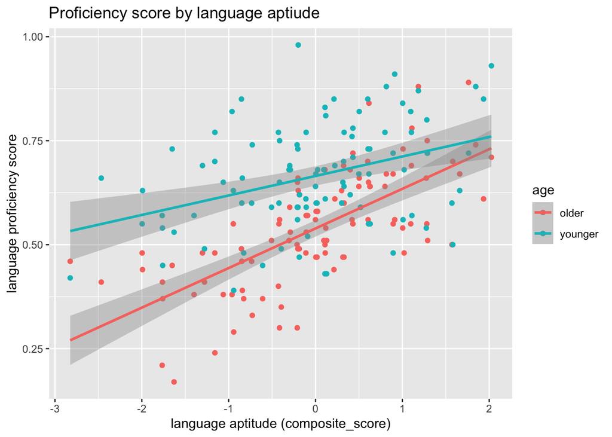

```r
plot <- ggplot(data_tidy, aes(x = composite_score, y = prof, color = age)) +
          geom_point() +
          geom_smooth(method = "lm") +
          xlab("language aptitude (composite_score)") +
          ylab("language proficiency score") +
          labs(title = "Proficiency score by language aptiude")#+
          # facet_wrap(~gender) # I don't think adding this next line is necessary, but it might be interesting to include the overall difference between male and female learners. Although the trend that younger participants being more proficient is true across both so it's not necessary.
plot
```

This plot shows a general trend that as composite_score (language aptitude) increases, so does proficiency. However, comparing older and younger participants, it looks as if younger participants begin with a higher proficiency and while they continue to have higher proficiency than old participants as their composite score increases, it also shows that given an increasing composite_score, older learners have a larger increase in proficiency than younger learners (as indicated by the slope of the fit line to the graph).

### 10. Again, you are interested in determining if proficiency scores vary as a function of age and composite_score. Fit the appropriate model. Test the two-way interaction, the main effect of age, and the main effect of composite_score.

```r
# null model
model_null <- lm(prof ~ 1, data = data_tidy)

# one predictor
model_1 <- lm(prof~age, data = data_tidy)

# two predictors
model_2 <- lm(prof~age+composite_score, data = data_tidy)

# interaction
model_3 <- lm(prof~age*composite_score, data = data_tidy)

nmc <- anova(model_null,model_1,model_2,model_3) # all significant, including predictors and interaction is justified
```

### 11. Print a summary of the best model and test that the model assumptions have been met (you can use plots for this, but you are not required to include them in the final version of your assignment).

```r
sum_mod_3 <- summary(model_3)
sum_mod_3
```

```
##
## Call:
## lm(formula = prof ~ age * composite_score, data = data_tidy)
##
## Residuals:
##      Min       1Q   Median       3Q      Max
## -0.24110 -0.06781  0.00171  0.07496  0.32423
##
## Coefficients:
##                            Estimate Std. Error t value Pr(>|t|)
## (Intercept)                 0.53900    0.01089  49.499  < 2e-16 ***
## ageyounger                  0.12610    0.01540   8.189 3.33e-14 ***
## composite_score             0.09521    0.01092   8.722 1.17e-15 ***
## ageyounger:composite_score -0.04837    0.01544  -3.133    0.002 **
## ---
## Signif. codes:  0 '***' 0.001 '**' 0.01 '*' 0.05 '.' 0.1 ' ' 1
##
## Residual standard error: 0.1089 on 196 degrees of freedom
## Multiple R-squared:  0.4518, Adjusted R-squared:  0.4434
## F-statistic: 53.85 on 3 and 196 DF,  p-value: < 2.2e-16
```

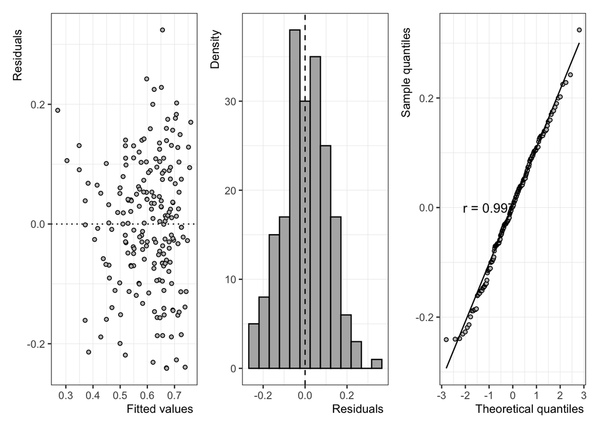

```r
ds4ling::diagnosis(model_3) #assumptions of normality of residuals and homoskedasticity seem good!
```

### 12. Write up the results. You should include a description of the statistical analyses you have done in one paragraph, and the actual results in another. Don’t forget to include an overall assessment of goodness of fit (variance explained).

Data of proficiency in a second language was analyzed using a general linear model. Proficiency was the criterion with age (younger/older) and language aptitude (referred to as composite score) as predictors. The age factor was dummy coded with older set as the reference group. Main effects and the *age* and *composite score* interaction were assessed using nested model comparison. Experiment-wise alpha was set at 0.05.